# A1 - Micaela Consens

Install packages & load libraries necessary.

```r
if (!requireNamespace("BiocManager", quietly = TRUE))
    install.packages("BiocManager")
if (!requireNamespace("GEOmetadb", quietly = TRUE))
    BiocManager::install("GEOmetadb")
if (!requireNamespace("gridExtra", quietly = TRUE))
    install.packages("gridExtra")
if (!requireNamespace("org.Hs.eg.db", quietly = TRUE))
    BiocManager::install("org.Hs.eg.db")
if (!requireNamespace("knitr", quietly = TRUE))
    install.packages("knitr")
if (!requireNamespace("biomaRt", quietly = TRUE))
    BiocManager::install("biomaRt")
if (!requireNamespace("edgeR", quietly = TRUE))
    BiocManager::install("edgeR")
if (!requireNamespace("RSQLite", quietly = TRUE))
    install.packages("RSQLite")
if (!requireNamespace("dplyr", quietly = TRUE))
    install.packages("dplyr")
if (!requireNamespace("tibble", quietly = TRUE))
    install.packages("tibble")
library(edgeR)
library(gridExtra)
library(knitr)
library(GEOmetadb)
library(biomaRt)
library(org.Hs.eg.db)
library(RSQLite)
library(magrittr)
library(dplyr)
library(tibble)
```

## Select a Dataset

```r
if(!file.exists('GEOmetadb.sqlite')) getSQLiteFile()
con <- dbConnect(SQLite(),'GEOmetadb.sqlite')
sql <- paste("SELECT DISTINCT gse.title,gse.gse, gpl.title,"," gse.submission_date,"," gse.supplementary_file","FROM","  gse JOIN gse_gpl ON gse_gpl.gse=gse.gse","  JOIN gpl ON gse_gpl.gpl=gpl.gpl","WHERE","  gse.submission_date > '2016-01-01' AND", "  gpl.organism LIKE '%Homo sapiens%' AND","  gpl.technology LIKE '%high-throughput sequencing%' ","  ORDER BY gse.submission_date DESC",sep=" ")
rs <- dbGetQuery(con,sql)
unlist(lapply(rs$supplementary_file,              FUN = function(x){x <- unlist(strsplit(x,";")) ;              x <- x[grep(x,pattern="txt",ignore.case = TRUE)];                tail(unlist(strsplit(x,"/")),n=1)})) [1:10]
```

```
##  [1] "GSE165625_HuR_KO_VS_CON.txt.gz"
##  [2] "GSE165624_readcount.txt.gz"
##  [3] "GSE165627_Normalized.txt.gz"
##  [4] "GSE165557_data_matrix.txt.gz"
##  [5] "GSE165532_VIS_ctrl_Wi38_norm_counts.txt.gz"
##  [6] "GSE165532_VIS_ctrl_Wi38_norm_counts.txt.gz"
##  [7] "GSE165452_ACY241_PRL_RNAseq_no_rRNA_Kallisto_Gene_Counts_matrix.txt.gz"
##  [8] "GSE165310_HNRNPU_rnaseq.txt.gz"
##  [9] "GSE165261_HuT78_Vorinostat.txt.gz"
## [10] "GSE165213_Smita_raw_readcounts_Mm.txt.gz"
```

```r
counts_files <- rs$supplementary_file[grep(rs$supplementary_file,                              pattern = "count",ignore.case = TRUE)]
```

The Expression Dataset I chose was [GSE97356: Gene expression associated with PTSD in World Trade Center responders: An RNA sequencing study](https://www.ncbi.nlm.nih.gov/geo/query/acc.cgi?acc=GSE97356).

**A bit about the dataset**

```r
gse <- getGEO("GSE97356",GSEMatrix=FALSE)
```

Dataset details:

| contact_address | contact_city | contact_country | contact_department | contact_email | contact_institute |
| --- | --- | --- | --- | --- | --- |
| ELM AND CARLTON STREETS | BUFFALO | USA | Biostatistics and Bioinformatics | eduardo.cortesgomez@roswellpark.org | ROSWELL PARK CANCER INSTITUTE |

Dataset platform details:

**Name of Platform:** Illumina HiSeq 2000 (Homo sapiens)

**Submission Data Date:** Nov 02 2010

**Last Date Data was Updated:** Mar 27 2019

**Organisms Included in Platform:** Homo sapiens

**Quantity of GEO datasets that use this Platform:** 8489

**Quantity of GEO samples that use this Platform:** 140433

## Clean the Data and Map to HUGO Symbols

**Downloading the data**

```r
if(!file.exists('GEOmetadb.sqlite')) getSQLiteFile()
con <- dbConnect(SQLite(),'GEOmetadb.sqlite')
sfiles <- getGEOSuppFiles('GSE97356')
fnames = rownames(sfiles)
reads = read.delim(fnames[1],header=TRUE,sep = ",")
#rename first column to genes, as it's more meaningful than X
colnames(reads)[1] <- c("Gene")
```

The dimensions of my dataset are: 25830, 325

This means there are 25830 rows and 325 columns (the rows indicate genes and the columns are samples, ignoring the first column which delimits that the rows are genes).

I have three kinds of samples in my 324 subjects, based on the study design. The study design says “324 human samples; 201 never, 82 current, 41 past with PTSD”. I want to get a list of which subjects have never/current/past PTSD diagnosis to compare to my reads dataframe.

```r
for(i in 1:324) {
    status <- gse@gsms[[i]]@header["characteristics_ch1"][[1]][1]
    case <- gse@gsms[[i]]@header["title"]
    if(i==1){
        metainfo <- data.frame("status"= status, "case" = case)
    }
    else{
        currentMetainfo <- data.frame("status"= status, "case" = case)
        metainfo <- rbind(metainfo, currentMetainfo)
    }
}
#for a sanity check ensure correct number of subjects with current/never/past PTSD diagnosis
occurences<-table(unlist(metainfo$status))
print(occurences)
```

```
##
## ptsd: Current   ptsd: Never    ptsd: Past
##            81           201            42
```

The metainformation found in the gse shows 81 subjects with current PTSD, 201 subjects who never had PTSD, and 42 who had past PTSD diagnosis. This doesn’t match the study design… but I looked at the paper and the published paper shows: “201 with never, 81 current, 42 past PTSD”, so we are actually correctly parsing the data, the study design is incorrectly labelled on GEO.

**Filter weakly expressed features from my dataset**

I’m going to filter lowly expressed genes using edgeR. Since I am keeping the genes that have at least 1 count per million within smallest group sample size, which is 42 (past PTSD), I’m looking for genes that have at least 1 count per million at least 42 times.

```r
cpms = cpm(reads[,2:325])
#add in the genes associated with rownames
rownames(cpms) <- reads[,1]
qualityReads = rowSums(cpms >1) >= 42
filteredReads = reads[qualityReads,]
```

The filtered dimensions of the dataset now are: 14184, 325.

During filtering we removed 11646 genes.

**Checking for duplicates after filtering**

I’m going to see if the dataset has duplicates:

```r
filteredReadsDf <- data.frame(table(filteredReads$Gene))
colnames(filteredReadsDf) <- c("Gene", "GeneOccurence")
duplicates <- filteredReadsDf %>% filter(GeneOccurence > 1)
```

It looks like I don’t have any duplicated gene names, the number of duplicated gene names is 0 .

Let’s take a look at how the gene names are stored:

```r
head(filteredReadsDf$Gene, 5)
```

```
## [1] A1BG     A1BG-AS1 A2M      A2M-AS1  A2MP1
## 14184 Levels: A1BG A1BG-AS1 A2M A2M-AS1 A2MP1 A3GALT2 AAAS AACS ... ZZZ3
```

Looking at gene AADACL2-AS1 for example, I see it is AADACL2 Antisense RNA 1. These appear to be gene ids, but I want to convert to HUGO symbols. I’m going to see if I can find the corresponding ensembl ids.

**Mapping to Ensembl Ids**

```r
grch37 <- useMart(biomart="ENSEMBL_MART_ENSEMBL", host="grch37.ensembl.org", path="/biomart/martservice") #from https://support.bioconductor.org/p/62064/
ensembl_grch37 = useDataset("hsapiens_gene_ensembl",mart=grch37)
idToEnsembl <- getBM(attributes = c("wikigene_name", "ensembl_gene_id"),
               filters = c("wikigene_name"),
               values = filteredReads$Gene,
               mart = ensembl_grch37)
```

I can see that I have 0 gene ids that do not map to ensembl ids, so I’m not concerned. I’m now going to convert the ensembl ids to HUGO symbols.

**Mapping to HUGO symbols**

```r
#first add the ensembl id labels to filteredReads
colnames(idToEnsembl) <- c("Gene", "EnsemblId")
filteredReads <- merge(idToEnsembl, filteredReads, by="Gene")
#now lets get the corresponding HUGO symbols
ensemblToHUGO <- getBM(attributes = c("ensembl_gene_id","hgnc_symbol"),
                   filters = c("ensembl_gene_id"),
                   values = filteredReads$EnsemblId,
                   mart = ensembl_grch37)
```

Now I have 413 ensembl ids that do not map to HUGO symbols. Lets see how many ensembl ids are duplicated.

**Checking for duplicates in Ensembl Ids**

```r
filteredReadsDfEnsembl <- data.frame(table(filteredReads$EnsemblId))
colnames(filteredReadsDfEnsembl) <- c("EnsemblGene", "GeneOccurence")
duplicates <- filteredReadsDfEnsembl %>% filter(GeneOccurence > 1)
length(duplicates$EnsemblGene)
```

```
## [1] 549
```

I have 549 duplicated ensembl ids. I wonder how large the overlap between the gene names that are duplicated and those that do not have HUGO symbols is.

```r
#first add the HUGO symbols to to filteredReads
colnames(ensemblToHUGO) <- c("EnsemblId", "HUGOSymbol")
filteredReads <- merge(ensemblToHUGO, filteredReads, by="EnsemblId")

emptyHUGO <- filteredReads %>% filter(HUGOSymbol == "")
duplicatedEnsembl <- data.frame(duplicates$EnsemblGene)
colnames(duplicatedEnsembl) <- c("EnsemblId")
overlapMissingDuplicated <- merge(emptyHUGO, duplicatedEnsembl, by="EnsemblId")
length(overlapMissingDuplicated$EnsemblId)
```

```
## [1] 117
```

It looks like there are 117 gene names that are duplicated ensembl ids and do not have HUGO symbols. The gene names that are missing HUGO symbols make up 3.0299283 % of the dataset. As some of these, 21.3114754 % exactly, have no corresponding HUGO symbol, but all have unique wikigene names, I’m not sure whether these genes are being mapped correctly and don’t feel comfortable removing them.

Additionally, according to lecture 4 slides 26 “if we base our analysis on ensembl gene ids then they are unique elements” as a comment not to necessarily filter out duplicates, and as I have removed lowly expressed genes I feel this is enough at this stage. Instead I’m going to try and preserve all these genes with duplicated names and just create versions of them so theyre unique. This is because the end goal of this assignment is to produce a dataframe with 324 numeric columns where each row has unique HUGO symbols as rownames. Lets see how many HUGO symbols are duplicated:

```r
filteredReadsDfHUGO <- data.frame(table(filteredReads$HUGOSymbol))
colnames(filteredReadsDfHUGO) <- c("HUGOGene", "GeneOccurence")
HUGOduplicates <- filteredReadsDfHUGO %>% filter(GeneOccurence > 1)
length(HUGOduplicates$HUGOGene)
```

```
## [1] 1061
```

There are 512 more duplicated HUGO symbols than ensembl ids. This is a lot.

```r
duplicatedHUGO <- data.frame(HUGOduplicates$HUGOGene)
colnames(duplicatedHUGO) <- c("HUGOSymbol")
duplicatedHUGOFull <- merge(duplicatedHUGO, filteredReads, by="HUGOSymbol")
duplicatedHUGOEnsembl <- merge(duplicatedHUGOFull, duplicatedEnsembl)
length(unique(duplicatedHUGOEnsembl$EnsemblId))
```

```
## [1] 549
```

This shows at least that all the duplicated ensembl ids also have duplicated HUGO symbols, so I’m really contending with the 512 duplicated HUGO symbol genes. I’m going to make the namings of these symbols unique so I can keep them all as discussed above. First I’m going to remove the ensembl ids that do not map to HUGO symbols, of which 117 are duplicated.

```r
filteredReadsFinal <- filteredReads %>% filter(HUGOSymbol != "")
```

I lost 490 genes that didn’t have HUGO symbols. Now I’m going to make the namings of the HUGO symbols unique.

```r
filteredReadsFinal <- filteredReadsFinal[, c(2,4:ncol(filteredReadsFinal))]
filteredReadsFinal$HUGOSymbol <- make.names(filteredReadsFinal$HUGOSymbol, unique=TRUE)
filteredReadsFinal <- tibble::column_to_rownames(filteredReadsFinal, var="HUGOSymbol")
```

## Apply Normalization

**Visualize the data**

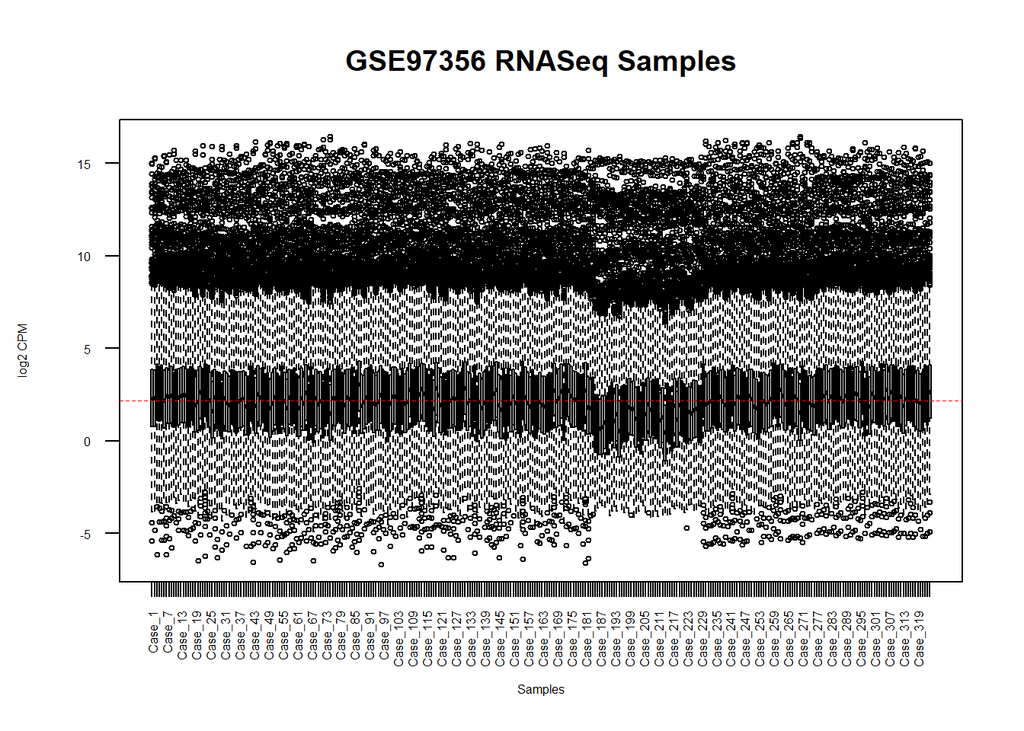

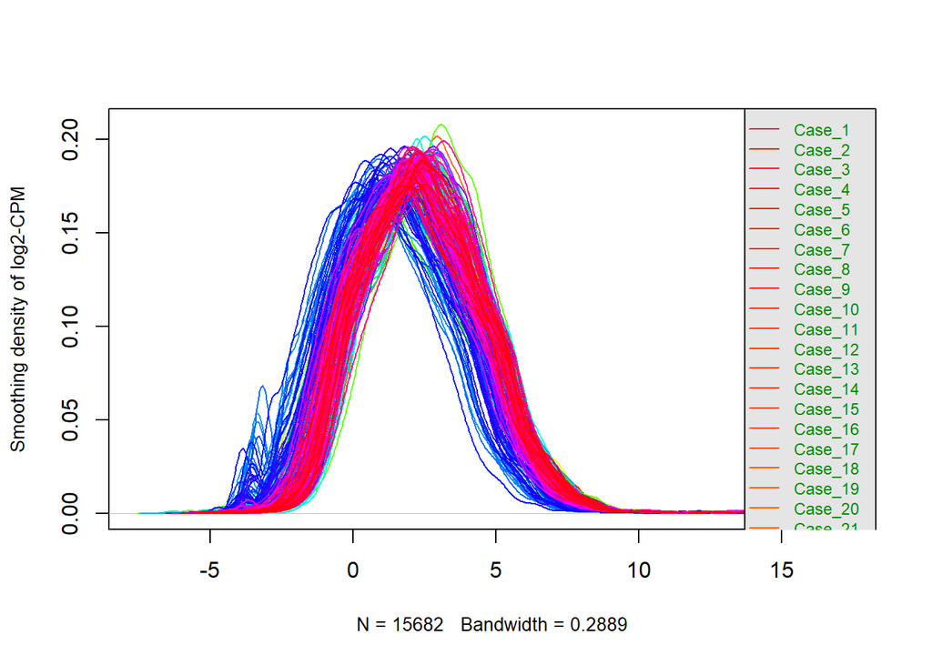

```r
countDensity <- apply(log2(cpm(filteredReadsFinal)), 2, density)
xlim <- 0; ylim <- 0
for (i in 1:length(countDensity)) {
  xlim <- range(c(xlim, countDensity[[i]]$x));
  ylim <- range(c(ylim, countDensity[[i]]$y))
}
cols <- rainbow(length(countDensity))
ltys <- rep(1, length(countDensity))
p1 <- plot(countDensity[[1]], xlim=xlim, ylim=ylim, type="n",
     ylab="Smoothing density of log2-CPM", main="", cex.lab = 0.85)
for (i in 1:length(countDensity)) lines(countDensity[[i]], col=cols[i], lty=ltys[i])
legend("topright", colnames(dataToPlot),
       col=cols, lty=ltys, cex=0.75,
       border ="blue",  text.col = "green4",
       merge = TRUE, bg = "gray90")
```

We can see some data is not following the same overall pattern as the other samples. Let’s normalize.

**Normalizing**

Let’s see if we can understand what happened visually.

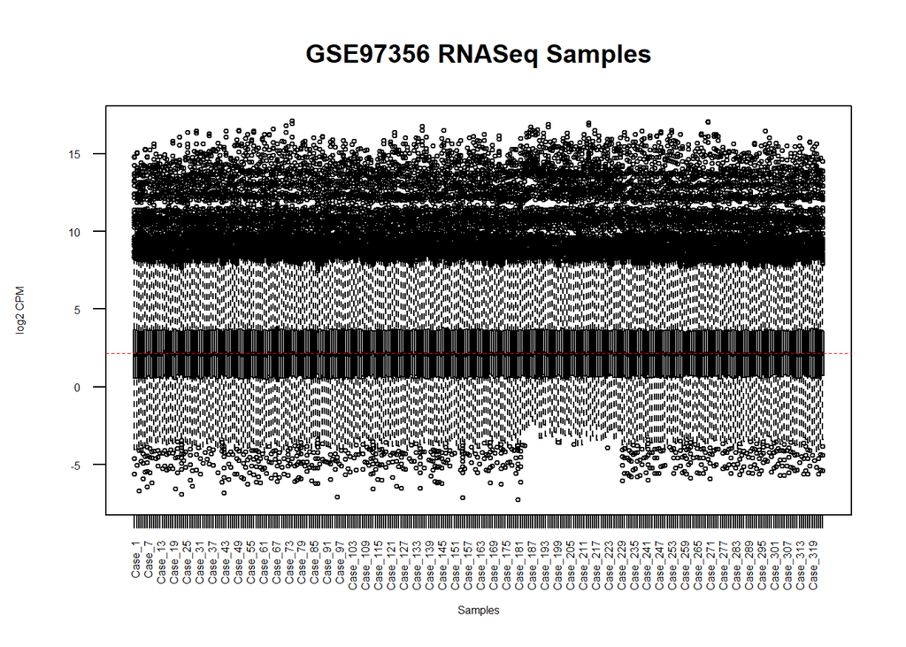

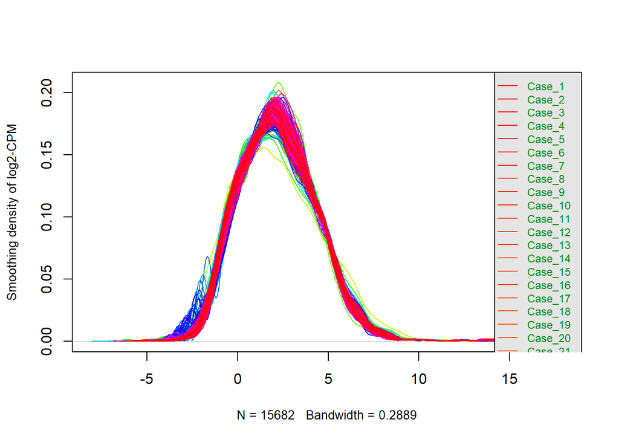

The boxplot is difficult to interpret, but you do see an adjustment towards the median especially between cases 181 to 223. The count density graph does also show a change in the dataset distribution after normalization. The patients are more tightly clustered, for one.

**MDS Plot**

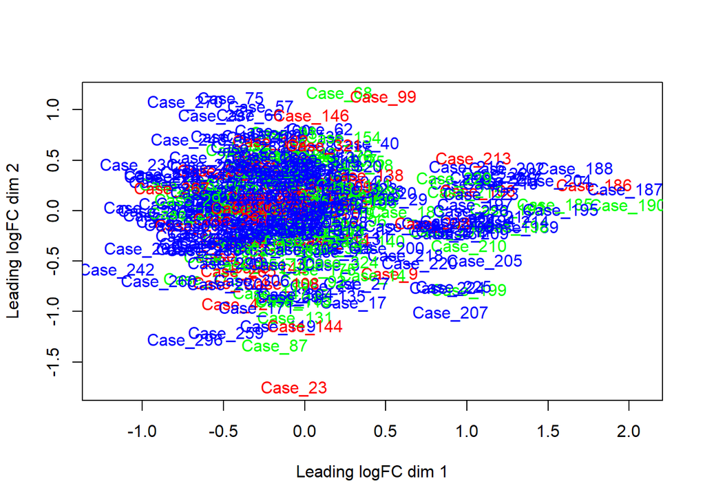

```r
plotMDS(d, labels=(metainfo$title), col = c("green","blue", "red")[factor(metainfo$status)])
```

Here the colour-coding is defined as follows: Blue are patients that have never had PTSD, red are patients that have been diagnosed in the past with PTSD, and green are patients that currently have PTSD.

Since MDS plot represents the distances between samples, we would hope to see past,never and current patients cluster together, but we don’t quite see this.

## References

1. Kuan PF, Waszczuk MA, Kotov R, Clouston S et al. Gene expression associated with PTSD in World Trade Center responders: An RNA sequencing study. Transl Psychiatry 2017 Dec 18;7(12):1297. PMID: 29249826
2. Marin-Garcia, P. (2015). How to use biomaRt with ensembl build 37. Retrieved from https://support.bioconductor.org/p/62064/
3. Sininho (2017, February 01). Is it OK to remove outliers from data? Retrieved from https://stats.stackexchange.com/questions/200534/is-it-ok-to-remove-outliers-from-data/200923